# TP 2 : Arbres

- Show All Code
- Hide All Code
- View Source

Author

EL ALLAKI Otmane

Published

September 28, 2023

# Question 1.

### Mesure d’homogénéité en régression

En régression, lorsque l’objectif est de prédire une valeur numérique pour la variable dépendante Y plutôt que de classifier en classes, une mesure d’homogénéité couramment utilisée est la somme des carrés des résidus (Sum of Squares of Residuals ou SSR). La SSR est également connue sous le nom de somme des carrés expliqués.

La SSR mesure la quantité totale de variabilité dans les données qui est expliquée par le modèle de régression. Elle est calculée comme la somme des carrés des différences entre les valeurs observées de Y et les valeurs prédites par le modèle de régression. Plus précisément, la formule de la SSR est la suivante :

$$SSR = \sum_{i=1}^{n} (y_i - \hat{y}_i)^2$$

Où :

- $y_i$ représente les valeurs observées de Y.
- $ŷ_i$ représente les valeurs prédites de Y par le modèle de régression.

Pour compléter l’analyse de la régression, on peut également calculer la somme des carrés totaux (Total Sum of Squares ou SST), qui mesure la variabilité totale des valeurs observées de Y sans prendre en compte le modèle de régression. La SST est calculée comme suit :

$$SST = \sum_{i=1}^{n} (y_i - \bar{y}_i)^2$$
Où $\bar{y}_i$ représente la moyenne des valeurs observées de Y.

La SSR est ensuite utilisée pour calculer le coefficient de détermination R², qui est une mesure de la proportion de la variabilité totale expliquée par le modèle de régression :

$$R^2 = \frac{SSR}{SST}$$

$R^2$ varie de 0 à 1, où une valeur plus proche de 1 indique un meilleur ajustement du modèle aux données.

*** Classification avec les arbres ***

Avec scikit-learn on peut construire des arbres de décision grâce au package tree. On obtient un classifieur avec **tree.DecisionTreeClassifier**.

```python
from sklearn import tree
```

```python
#importer les librairies nécessaires
import os
import numpy as np
import matplotlib.pyplot as plt
import seaborn as sns
from matplotlib import rc
import random
from sklearn import tree, datasets
from sklearn.metrics import accuracy_score
from sklearn.tree import DecisionTreeClassifier
from tp_arbres_source import (rand_gauss, rand_bi_gauss, rand_tri_gauss,
                              rand_checkers, rand_clown,
                              plot_2d, frontiere)
```

# Qestion 2

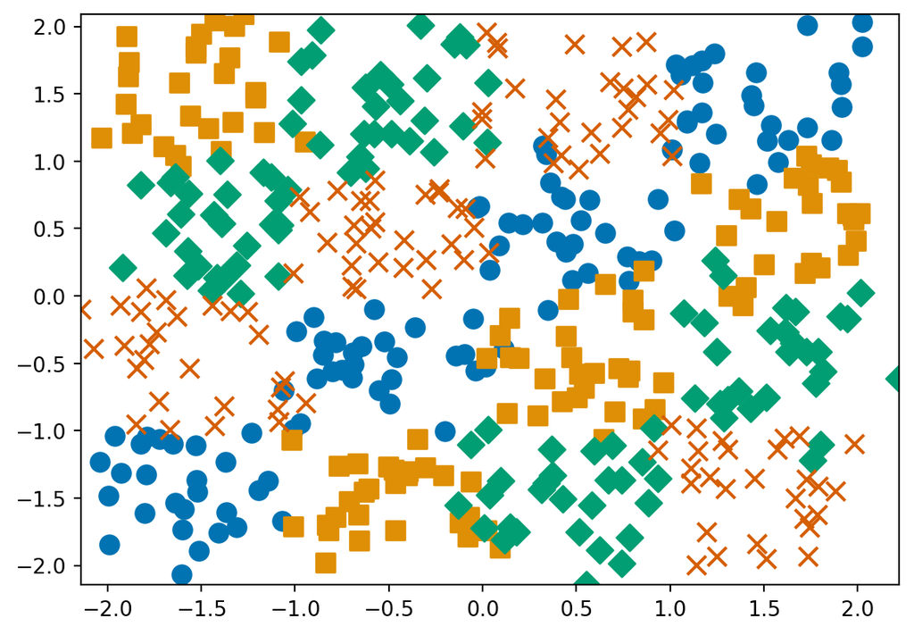

Simulation d’échantillons avec randcheckers

```python
np.random.seed(1)
n1 = 114
n2 = 114
n3 = 114
n4 = 114
sigma = 0.1
data4 = rand_checkers(n1, n2, n3, n4, sigma)

plot_2d(data4[:, :2], data4[:, 2], w=None)
plt.show()
```

Créion deux objets ‘arbre de décision’ en spécifiant le critère de classification comme l’indice de gini ou l’entropie, avec la fonction ‘DecisionTreeClassifier’ du module ‘tree’.

```python
dt_entropy = tree.DecisionTreeClassifier(criterion = "entropy" )
dt_gini = tree.DecisionTreeClassifier()
```

Séparons les données en variable X (variable explicative) et variable Y (variable à expliquer

```python
n_samples = len(data4)
X = data4[:, 0:2]
Y = data4[:, 2]
```

Affichons les scores en fonction du paramètre max_depth

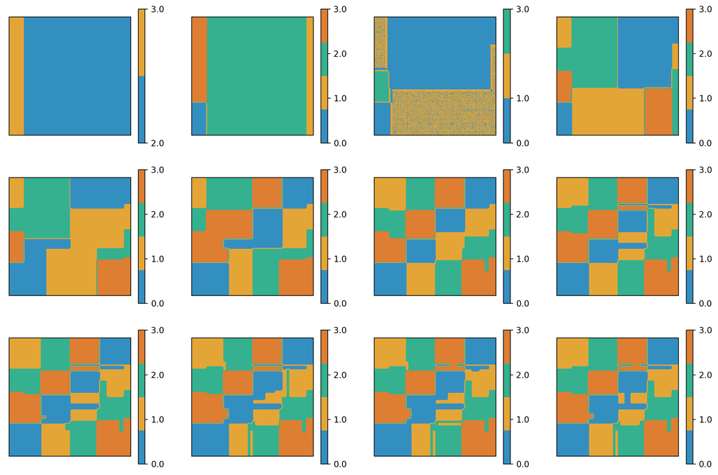

```python
dmax = 12
scores_entropy = np.zeros(dmax)
scores_gini = np.zeros(dmax)

plt.figure(figsize=(15, 10))
for i in range(dmax):
    # max_depth=None
    dt_entropy = tree.DecisionTreeClassifier(criterion = "entropy", max_depth=(i+1) )
    # ...
    dt_entropy.fit(X, Y)
    scores_entropy[i] = dt_entropy.score(X, Y)

    dt_gini =  tree.DecisionTreeClassifier(max_depth=(i+1) )
    dt_gini.fit(X, Y)
    scores_gini[i] = dt_gini.score(X,Y)

    plt.subplot(3, 4, i + 1)
    frontiere(lambda x: dt_gini.predict(x.reshape((1, -1))), X, Y, step=50, samples=False)
plt.draw()
```

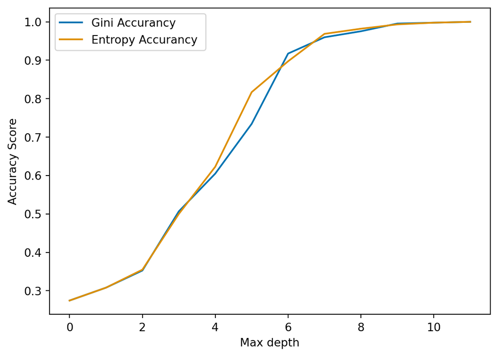

le pourcentage d’accurancy commises en fonction de la profondeur maximale de l’arbre

```python
plt.figure()
plt.plot(scores_gini, label = "Gini Accurancy ")
plt.plot(scores_entropy,  label = "Entropy Accurancy ")
plt.xlabel('Max depth')
plt.ylabel('Accuracy Score')
plt.legend()
plt.draw()
```

# Question 3

Affichons la classification obtenue en utilisant la profondeur qui minimise le pourcentage d’erreurs obtenues avec l’entropie.

```python
best_depth_entropy = np.argmax(scores_entropy)
best_score_entropy = scores_entropy[best_depth_entropy-1]
print("Best depth for Entropy: ", best_depth_entropy)
print("Best accuracy with Entropy: ", best_score_entropy)
```

```
Best depth for Entropy:  11
Best accuracy with Entropy:  0.9977678571428571
```

```
Best scores with entropy criterion:  1.0
```

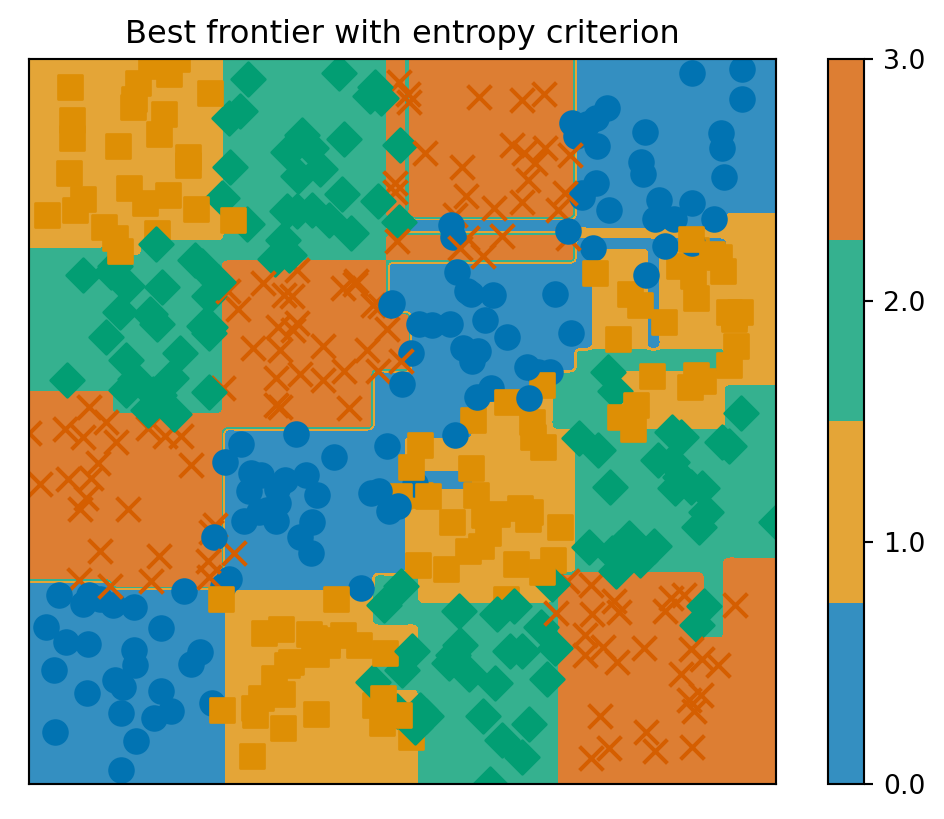

```python
plt.figure()
frontiere(lambda x: dt_entropy.predict(x.reshape((1, -1))), X, Y, step=100)
plt.title("Best frontier with entropy criterion")
plt.draw()
print("Best scores with entropy criterion: ", dt_entropy.score(X, Y))
```

# Question 4

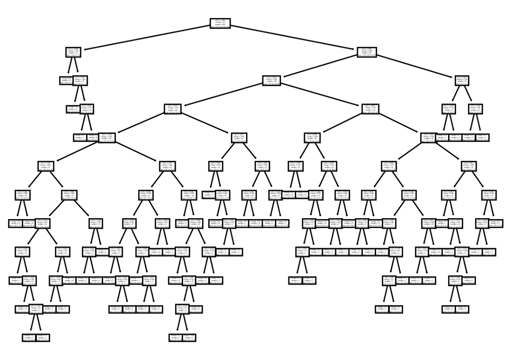

```python
dt_entropy = tree.DecisionTreeClassifier(criterion = "entropy", max_depth=11)
clf = dt_entropy.fit(X,Y)
fig = tree.plot_tree(clf)
plt.savefig("./plots/TreeModel.pdf")
```

# Question 5

Nous allons créer un nouvel ensemble de données comprenant un total de n = 160 échantillons, répartis équitablement avec 40 échantillons pour chaque classe en utilisant la fonction rand_checkers(). Ensuite, nous évaluerons la performance des arbres de décision que nous avons précédemment entraînés en calculant la proportion d’erreurs sur cet échantillon de test.

```python
# Génération d'une base de test
data_test = rand_checkers(n1 = 40, n2=40, n3=40, n4=40)
X_test = data_test[:,0:2]
Y_test = data_test[:,2]

test_dt_ent_score = dt_entropy.score(X_test,Y_test)
test_dt_gini_score = dt_gini.score(X_test, Y_test)

print("Proportion d'accurancy sur le nouvel échantillon (Entropy): {:.2f}%".format(test_dt_ent_score * 100))
print("Proportion d'accurancy sur le nouvel échantillon (Gini): {:.2f}%".format(test_dt_gini_score * 100))
```

```
Proportion d'accurancy sur le nouvel échantillon (Entropy): 86.25%
Proportion d'accurancy sur le nouvel échantillon (Gini): 85.00%
```

On remarque que le score de l’arbre calculé à partir de l’indice de Gini est inférieur à celui calculé par l’entropie. Ainsi, les deux scores sont plus bas que ceux calculés sur les échantillons d’entraînement. Pour évaluer le modèle, il sera nécessaire d’utiliser la méthode de **validation croisée**.

# Question 6

Modélisons la reconnaissance des chiffres à l’aide d’un modèle **d’arbre de décision** en utilisant un jeu de données disponible dans le module **sklearn.datasets**.

```python
digits = datasets.load_digits()
n_samples = len(digits.data)
# use test_train_split rather.

X_digits = digits.data[:n_samples // 2]  # digits.images.reshape((n_samples, -1))
Y_digits = digits.target[:n_samples // 2]
X_test = digits.data[n_samples // 2:]
Y_test = digits.target[n_samples // 2:]
```

le pourcentage d’accurancy en fonction de la profondeur maximale de l’arbre

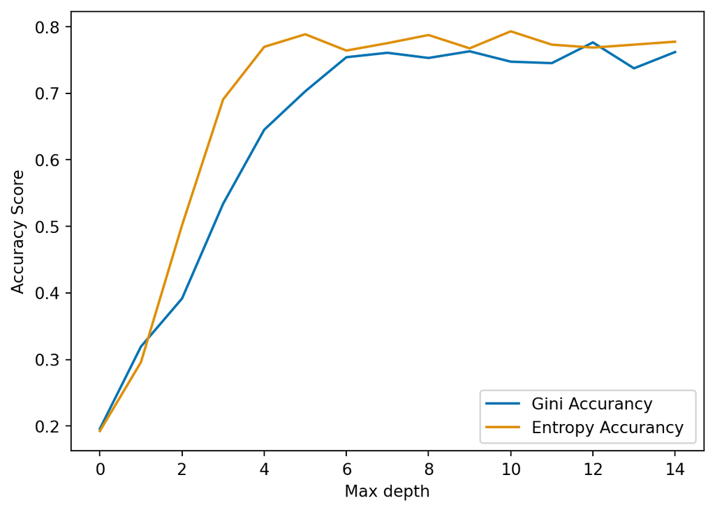

```python
digits = datasets.load_digits()

n_samples = len(digits.data)
# use test_train_split rather.

X_digits = digits.data[:n_samples // 2]  # digits.images.reshape((n_samples, -1))
Y_digits = digits.target[:n_samples // 2]
X_digits_test = digits.data[n_samples // 2:]
Y_digits_test = digits.target[n_samples // 2:]

d_max = 15
scores_entropy = np.zeros(d_max)
scores_gini = np.zeros(d_max)

plt.figure(figsize=(15, 10))
for i in range(d_max):
    # max_depth=None
    dt_entropy = tree.DecisionTreeClassifier(criterion = "entropy", max_depth=(i+1) )
    dt_entropy.fit(X_digits, Y_digits)
    scores_entropy[i] = dt_entropy.score(X_digits_test, Y_digits_test)

    dt_gini =  tree.DecisionTreeClassifier(max_depth=(i+1) )
    dt_gini.fit(X_digits, Y_digits)
    scores_gini[i] = dt_gini.score(X_digits_test,Y_digits_test)

plt.figure()
plt.plot(scores_gini, label = "Gini Accurancy ")
plt.plot(scores_entropy,  label = "Entropy Accurancy ")
plt.xlabel('Max depth')
plt.ylabel('Accuracy Score')
plt.legend()
plt.draw()
```

Nous extrairons la profondeur qui minimise le pourcentage d’erreurs obtenues avec l’entropie

```python
best_depth_entropy = np.argmax(scores_entropy)
best_score_entropy = scores_entropy[best_depth_entropy-1]
print("Best depth for Entropy: ", best_depth_entropy)
print("Best accuracy with Entropy: ", best_score_entropy)
```

```
Best depth for Entropy:  10
Best accuracy with Entropy:  0.7675194660734149
```

# Question 7

estimer la meilleur profondeur avec un cross_val_score

```python
from sklearn.model_selection import cross_val_score
dmax = 20
scores = np.ones(dmax)

for i in range (dmax):
    clf = tree.DecisionTreeClassifier(criterion = "entropy", max_depth=i+1)
    scores[i] = np.mean(cross_val_score(clf, digits.data, digits.target, cv=5))
tmax = np.argmax(scores)
print("la meilleur profondeur avec un cross_val_score est : ", tmax)
```

```
la meilleur profondeur avec un cross_val_score est :  9
```